# Efenwengbe_Cardio_Project 1

```python
import warnings
warnings.filterwarnings('ignore') #library to handle warnings without interrupting the program
```

```python
import numpy as np               #To handle arrays
import pandas as pd              #To handle dataframes and their operations

#To handle data visualisation
import matplotlib.pyplot as plt
import seaborn as sns
sns.set_style('darkgrid')
sns.set_context("paper", font_scale=1.5, rc={"font_size":16,"axes.titlesize":16,"axes.labelsize":16})

%matplotlib inline
```

```python
#For hypothesis testing
import scipy.stats as stats
from scipy.stats import normaltest
from scipy.stats import pearsonr
from scipy.stats import spearmanr
from scipy.stats import kendalltau
from statsmodels.stats.weightstats import CompareMeans
from statsmodels.stats.proportion import proportions_ztest
```

```python
#Packages mainly for Anova
import statsmodels.api as sm
import statsmodels.formula.api as smf
from statsmodels.formula.api import ols
from statsmodels.stats.anova import anova_lm
import statsmodels.stats.multicomp as multi
```

```python
data=pd.read_csv('CardioGoodFitness.csv') # Importing dataset
```

```python
data.shape # Define shape of the data
```

```
(180, 9)
```

The imported dataset originally has 180 rows and 9 columns

```python
data.head() # To view some part of the dataset
```

|  | Product | Age | Gender | Education | MaritalStatus | Usage | Fitness | Income | Miles |
| --- | --- | --- | --- | --- | --- | --- | --- | --- | --- |
| 0 | TM195 | 18 | Male | 14 | Single | 3 | 4 | 29562 | 112 |
| 1 | TM195 | 19 | Male | 15 | Single | 2 | 3 | 31836 | 75 |
| 2 | TM195 | 19 | Female | 14 | Partnered | 4 | 3 | 30699 | 66 |
| 3 | TM195 | 19 | Male | 12 | Single | 3 | 3 | 32973 | 85 |
| 4 | TM195 | 20 | Male | 13 | Partnered | 4 | 2 | 35247 | 47 |

```python
data.info()  # Information about the data including data type, rows and columns
```

```
<class 'pandas.core.frame.DataFrame'>
RangeIndex: 180 entries, 0 to 179
Data columns (total 9 columns):
 #   Column         Non-Null Count  Dtype
---  ------         --------------  -----
 0   Product        180 non-null    object
 1   Age            180 non-null    int64
 2   Gender         180 non-null    object
 3   Education      180 non-null    int64
 4   MaritalStatus  180 non-null    object
 5   Usage          180 non-null    int64
 6   Fitness        180 non-null    int64
 7   Income         180 non-null    int64
 8   Miles          180 non-null    int64
dtypes: int64(6), object(3)
memory usage: 12.8+ KB
```

six (6) of the features are of integer data type (age, education, usage, fitness, income, and miles), while the remaining three are of object data type (product, gender, and marital status)

# Let's define a function to check for missing data

```python
def missing_data_check(df):
    total = df.isnull().sum().sort_values(ascending=False)                              # total number of null values
    grand_total=df.isnull().count().sort_values(ascending=False)                        # total number of data entry
    percent = (total*100/grand_total)                                                   # percentage of values that are null
    missing_data = pd.concat([total, percent], axis=1, keys=['Total', 'Percent'])       # putting the above two together
    return missing_data                                                                 # return the dataframe
missing_data_check(data)
```

|  | Total | Percent |
| --- | --- | --- |
| Product | 0 | 0.0 |
| Age | 0 | 0.0 |
| Gender | 0 | 0.0 |
| Education | 0 | 0.0 |
| MaritalStatus | 0 | 0.0 |
| Usage | 0 | 0.0 |
| Fitness | 0 | 0.0 |
| Income | 0 | 0.0 |
| Miles | 0 | 0.0 |

So, no missing data in the dataset (or data fields)

```python
data.describe() # check distribution of the numeric data fields
```

|  | Age | Education | Usage | Fitness | Income | Miles |
| --- | --- | --- | --- | --- | --- | --- |
| count | 180.000000 | 180.000000 | 180.000000 | 180.000000 | 180.000000 | 180.000000 |
| mean | 28.788889 | 15.572222 | 3.455556 | 3.311111 | 53719.577778 | 103.194444 |
| std | 6.943498 | 1.617055 | 1.084797 | 0.958869 | 16506.684226 | 51.863605 |
| min | 18.000000 | 12.000000 | 2.000000 | 1.000000 | 29562.000000 | 21.000000 |
| 25% | 24.000000 | 14.000000 | 3.000000 | 3.000000 | 44058.750000 | 66.000000 |
| 50% | 26.000000 | 16.000000 | 3.000000 | 3.000000 | 50596.500000 | 94.000000 |
| 75% | 33.000000 | 16.000000 | 4.000000 | 4.000000 | 58668.000000 | 114.750000 |
| max | 50.000000 | 21.000000 | 7.000000 | 5.000000 | 104581.000000 | 360.000000 |

Mean age, education, usage, fitness, income, and miles are approximately 29 years, 16 years, 3.5, 3.3, £53720, and 103 miles respectively. Their corresponding median values are 26 years, 16 years, 3, 3, £50600 and 94 miles. The mean education corresponds to the median - showing a possibility of normal distribution. Also, other features may show normal distribution, but to confirm normality, let's use further data visualisation tools.

# Univariate Data Analysis

Hypothesis Ho: The data field is normally distributed H1: The data field is not normally distributed

```python
normaltest(data['Age'])
```

```
NormaltestResult(statistic=24.013245406896093, pvalue=6.103655503221668e-06)
```

Since p-value < 0.05, we reject the null hypothesis for Age. So, ages of the customers are not normally distributed.

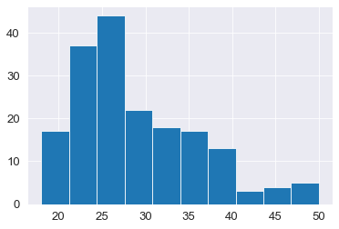

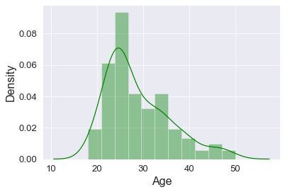

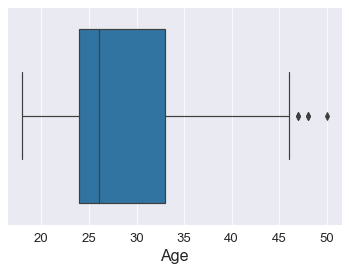

```python
plt.hist(data.Age)
plt.show()
sns.distplot(data['Age'],color='g')
plt.show()
sns.boxplot(x='Age',data=data)
plt.show()
```

Age is not normally distributed, but instead skewed towards the right. Over 75% of the customers have ages below 33 years. Ages above 46 years are merely outliers.

```python
normaltest(data['Education'])
```

```
NormaltestResult(statistic=15.65315956322462, pvalue=0.0003989877746126755)
```

Since p-value < 0.05, we reject the null hypothesis on Education. So, education of the customers are not normally distributed.

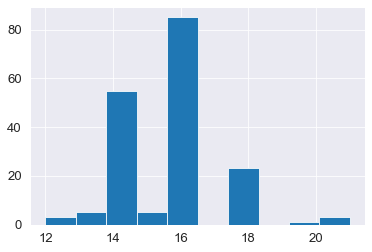

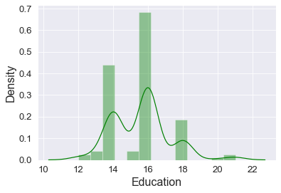

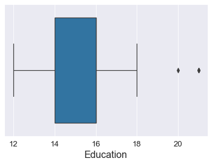

```python
plt.hist(data.Education)
plt.show()
sns.distplot(data['Education'],color='g')
plt.show()
sns.boxplot(x='Education',data=data)
plt.show()
```

Education is not normally distributed, but the distribution of relevant part of the data is quite symmetric. Education levels above 18 years are merely outliers.

```python
normaltest(data['Usage'])
```

```
NormaltestResult(statistic=16.360208150182817, pvalue=0.0002801727796036487)
```

Since p-value < 0.05, we reject the null hypothesis on Usage. So, usage of treadmill by customers is not normally distributed.

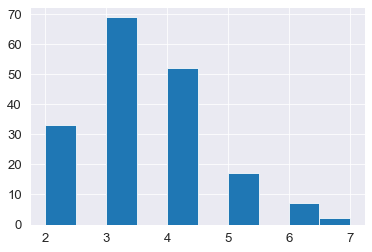

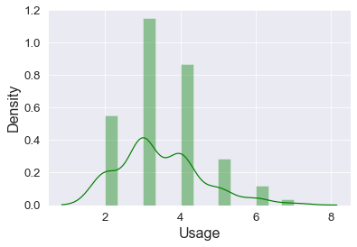

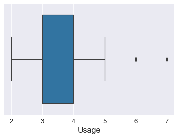

```python
plt.hist(data.Usage)
plt.show()
sns.distplot(data['Usage'],color='g')
plt.show()
sns.boxplot(x='Usage',data=data)
plt.show()
```

Usage is not normally distributed, but the distribution of relevant part of the data is quite symmetric. Usage above 5 times per week are merely outliers.

```python
normaltest(data['Fitness'])
```

```
NormaltestResult(statistic=7.316631064402506, pvalue=0.02577589484305985)
```

Since p-value < 0.05, we reject the null hypothesis on Fitness. So, fitness of the customers is not normally distributed.

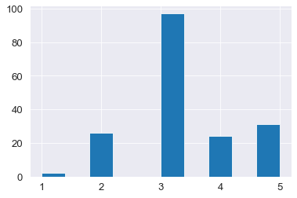

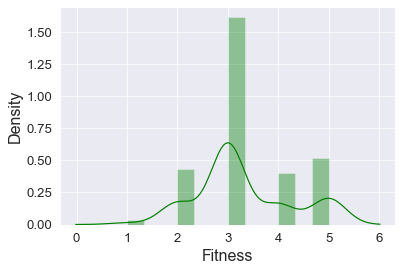

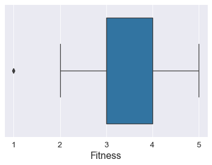

```python
plt.hist(data.Fitness)
plt.show()
sns.distplot(data['Fitness'],color='g')
plt.show()
sns.boxplot(x='Fitness',data=data)
plt.show()
```

Fitness is not normally distributed, but the distribution of relevant part of the data is quite symmetric. Fitness below two (2) are merely outliers.

```python
normaltest(data['Income'])
```

```
NormaltestResult(statistic=41.16569129708731, pvalue=1.1507572321269166e-09)
```

Since p-value < 0.05, we reject the null hypothesis on Income. So, income of the customers are not normally distributed.

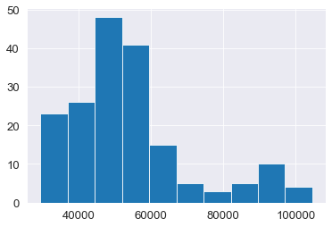

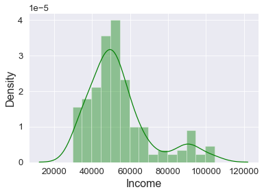

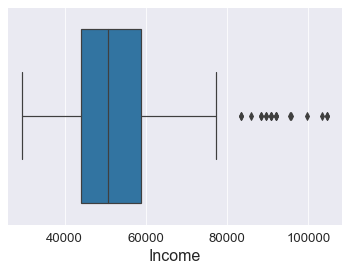

```python
plt.hist(data.Income)
plt.show()
sns.distplot(data['Income'],color='g')
plt.show()
sns.boxplot(x='Income',data=data)
plt.show()
```

Income is not normally distributed, but instead skewed towards the right. Over 75% of the customers' income is below £58668. Income over £78000 are merely outliers.

```python
normaltest(data['Miles'])
```

```
NormaltestResult(statistic=73.61857789249362, pvalue=1.032592408553557e-16)
```

Since p-value < 0.05, we reject the null hypothesis on Miles. So, miles covered by customers are not normally distributed.

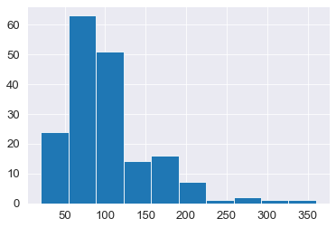

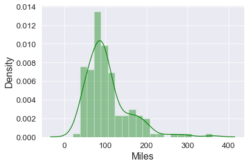

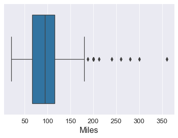

```python
plt.hist(data.Miles)
plt.show()
sns.distplot(data['Miles'],color='g')
plt.show()
sns.boxplot(x='Miles',data=data)
plt.show()
```

Miles covered by customers are not normally distributed, but instead skewed towards the right. Over 75% of miles covered by customers is below 125 miles. Miles over 180 (miles) are merely outliers and statistically irrelevant.

# Univariate data analysis for categorical data

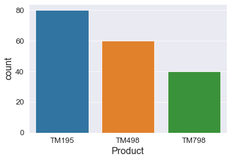

```python
sns.countplot(data['Product'])
plt.show()
```

Most of the customers use TM195 (product), followed by TM498, and the least used product is TM798. In other words, 80 customers out of 180 use TM195, while 60 customers use TM498, and the remaining 40 customers use TM798.

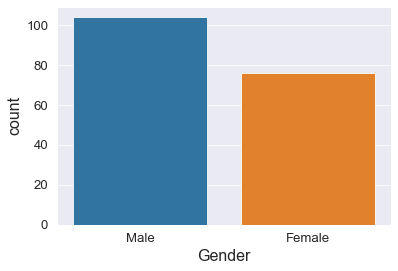

```python
sns.countplot(data['Gender'])
plt.show()
```

Over 100 customers out of 180 are male, while the remaining customers are female.

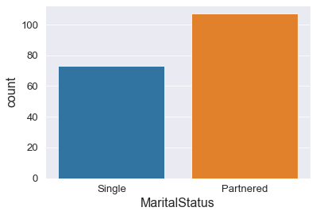

```python
sns.countplot(data['MaritalStatus'])
plt.show()
```

Over 100 customers are have partners (or are married), while the remaining customers are single.

Based on univariate data analysis, none of the numeric features is normally distributed - majority of them are skewed (distributed) towards the right and full of outliers. Also, majority of the customers use TM195 product and least of TM798 product. Furthermore, most of the customers are male, and majority of the customers have at least a partner compared to the single ones.

To understand interaction between features in the dataset, let's conduct a multivariate data analysis.

# Multivariate Data Analysis

To avoid ambiguity in analysis, let's focus more on the relationship between age (or income) and usage (and fitness) as these features are more important in this analysis. Then we can ascertain whether age (or income) of customers affect their exercise product usage (and fitness). We can have a rough picture of the relationship between each of the features below.

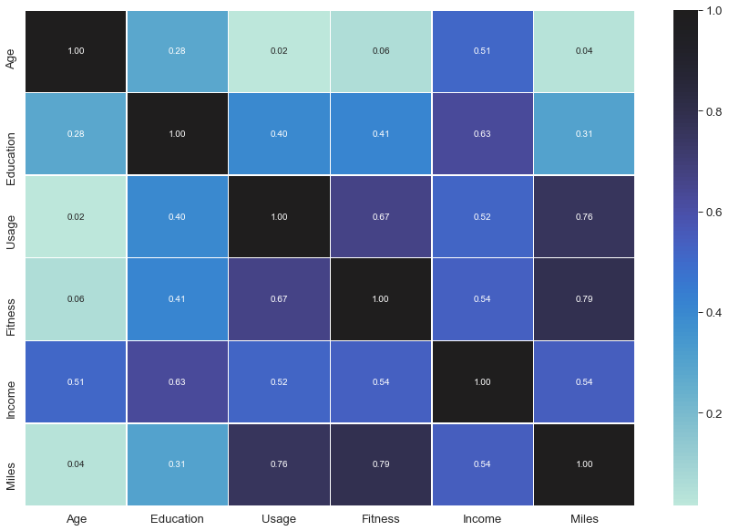

```python
plt.figure(figsize=(15,10))
sns.heatmap(data.corr(), annot=True, linewidths=.5, fmt= '.2f', center = 1 )  # heatmap
plt.show()
```

Let's use a benchmark correlation coefficient of 0.5.

The heatmap (correlation) shows that, there is no relationship between Age and (Education, Usage, Fitness, or Miles).

However, there appears to be a slight positive relationship between Age and Income (0.51).

Furthermore, there is a positive relationship between Income and (Age, Education, Usage, Fitness or Miles)

There is a positive relationship between Fitness and (Usage, Income, or Miles)

There is a positive relationship between Usage and (Fitness, Income, or Miles)

There is a positive relationship between Education and Income (0.63). It appears that the higher the education level the more income a customer gets.

There is a positive relationship between Miles and (Usage, Fitness, or Income)

However, there is a more significant relationship between Miles and (Usage or Fitness). This shows that the higher the miles covered, the more fit a customer is (0.79). Moreover, the more miles covered depends on the amount of usage (0.76). Inferentially, the more usage of the treadmill, the higher a customer's level of finess (0.67).

But, the positive relationship between Income and Usage (or Fitness) is not very significant (0.52-0.54). So, there is a chance that not all income range of customers impact usage (or fitness).

Also, even though there is no relationship between Age and Usage (Fitness), it's possible that some age range might impact usage (or fitness).

See the pairplot below for graphical representation of the correlations.

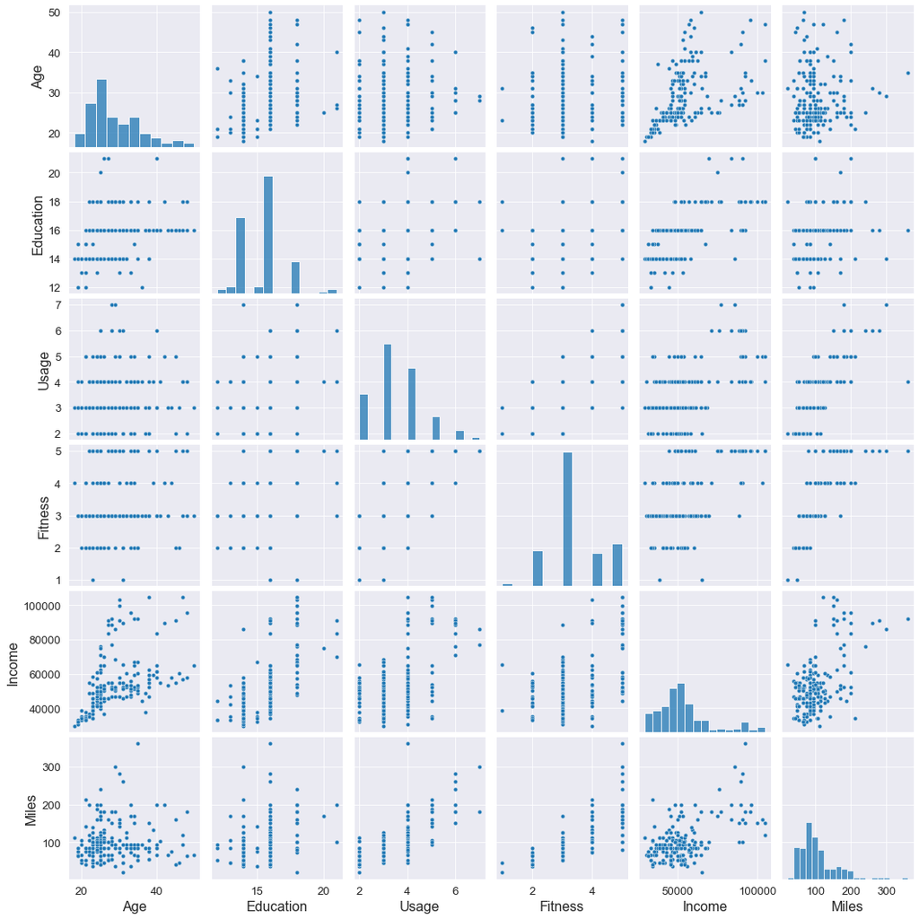

```python
sns.pairplot(data)
plt.show()
```

Let's take the analysis further to get a clearer relationship.

```python
data.groupby(by=['Usage'])['Miles'].mean()
```

```
Usage
2     58.545455
3     83.420290
4    118.942308
5    160.705882
6    212.857143
7    240.000000
Name: Miles, dtype: float64
```

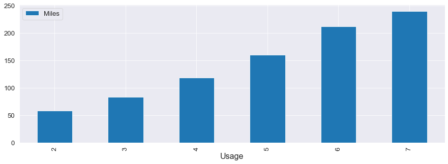

```python
data.groupby(by=['Usage'])['Miles'].mean().reset_index().sort_values(['Miles']).plot(x='Usage',
                                                                                                           y='Miles',
                                                                                                           kind='bar',
                                                                                                           figsize=(15,5))
plt.show()
```

Miles covered increase with Usage

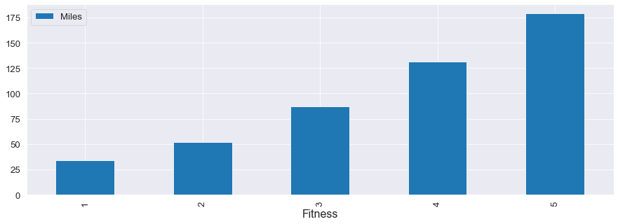

```python
data.groupby(by=['Fitness'])['Miles'].mean().reset_index().sort_values(['Miles']).plot(x='Fitness',
                                                                                                           y='Miles',
                                                                                                           kind='bar',
                                                                                                           figsize=(15,5))
plt.show()
```

Fitness increases with amount of Miles covered.

```python
data.groupby(by=['Usage'])['Fitness'].mean()
```

```
Usage
2    2.515152
3    3.000000
4    3.596154
5    4.411765
6    4.857143
7    5.000000
Name: Fitness, dtype: float64
```

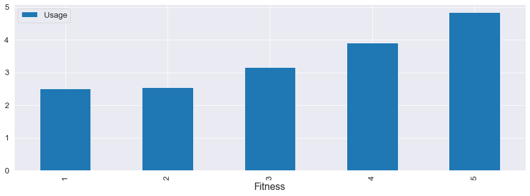

```python
data.groupby(by=['Fitness'])['Usage'].mean().reset_index().sort_values(['Usage']).plot(x='Fitness',
                                                                                                           y='Usage',
                                                                                                           kind='bar',
                                                                                                           figsize=(15,5))
plt.show()
```

Fitness increases with Usage.

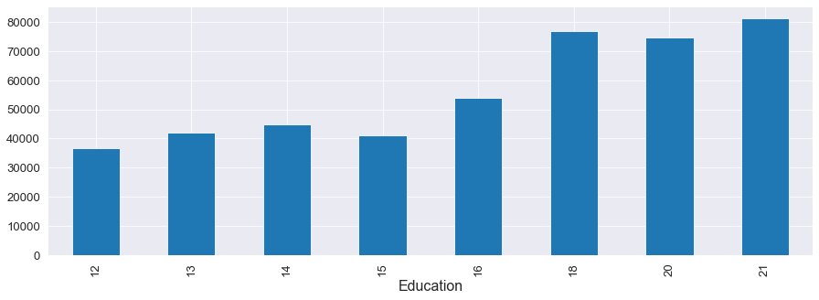

```python
data.groupby(by=['Education'])['Income'].mean().plot(x='Education', y='Income', kind='bar', figsize=(15,5))
plt.show()
```

Generally, income of customers increases with their level of education. However, the trend was not sustained for mean education of 15 and 20 years.

```python
data.groupby(by=['Usage'])['Education'].mean()
```

```
Usage
2    14.939394
3    15.115942
4    15.942308
5    16.529412
6    17.857143
7    16.000000
Name: Education, dtype: float64
```

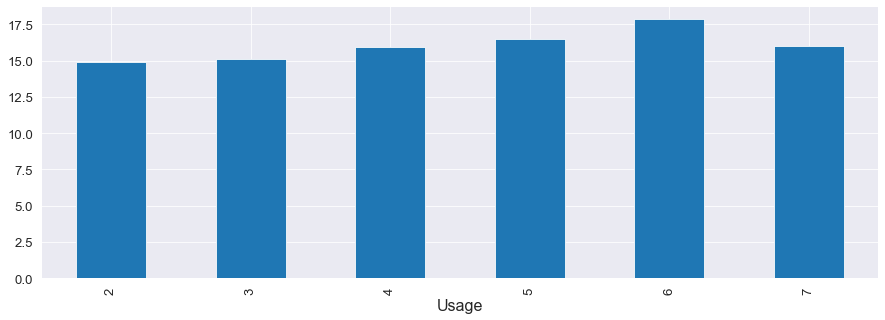

```python
data.groupby(by=['Usage'])['Education'].mean().plot(x='Education', y='Usage', kind='bar', figsize=(15,5))
plt.show()
```

Customers whose period of education is 15 years, use the treadmill 2-3 times per week; while those with higher level of education uses the facility a bit more and increases as education (years) increases. However, the education of customers who use the treadmill 7 times per week is the same as those who use the facility 4 times per week. Thus, we can't really justify that education impacts usage of the treadmill.

```python
data.groupby(by=['Usage'])['Income'].mean()
```

```
Usage
2    46870.636364
3    47921.753623
4    56403.442308
5    66396.117647
6    84483.142857
7    81548.500000
Name: Income, dtype: float64
```

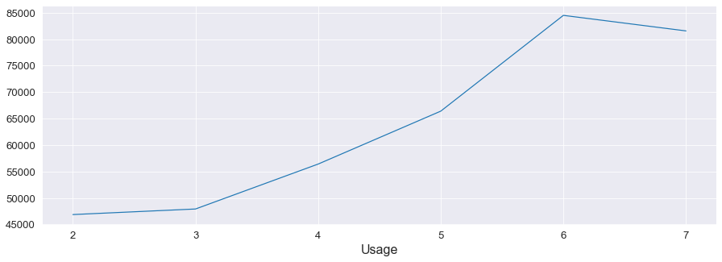

```python
data.groupby(by=['Usage'])['Income'].mean().plot(x='Usage', y='Income', kind='line', figsize=(15,5))
plt.show()
```

Amount of usage increases as income of customers increases. However, customers who use the treadmill up to 7 times per week earn a little bit less than those who use the facility 6 times per week. So, one can not really justify whether income significantly impacts usage.

```python
data.groupby(by=['Usage'])['Age'].mean()
```

```
Usage
2    28.484848
3    28.985507
4    28.538462
5    29.058824
6    29.571429
7    28.500000
Name: Age, dtype: float64
```